# Kolokwium 31.01.2023 - zadanie 1

Do zadań należy wykorzystać zbiór danych `Arrests` z biblioteki `carData` dotyczący aresztowań osób w Toronto za posiadanie niewielkich ilości marihuany. Przed przystąpieniem do zadań należy zapoznać się ze zbiorem w zakładce Help.

1. **(1 pkt.)** Przy pomocy pakietu funkcji `group_by` oraz `summarise` i `n()`, stwórz ramkę danych, w której dla każdego roku będzie informacja ile osób zostało zwolnionych z aresztu po zatrzymaniu, a ile nie.

```
## # A tibble: 12 × 3
## # Groups:   year [6]
##     year released count
##    <int> <fct>    <int>
##  1  1997 No         116
##  2  1997 Yes        376
##  3  1998 No         154
##  4  1998 Yes        723
##  5  1999 No         184
##  6  1999 Yes        915
##  7  2000 No         178
##  8  2000 Yes       1092
##  9  2001 No         205
## 10  2001 Yes       1006
## 11  2002 No          55
## 12  2002 Yes        222
```

2. **(1 pkt.)** Przekształć ramkę z pkt 1. na szeroką rozbijając kolumnę `release` na dwie kolumny.

```
## # A tibble: 6 × 3
## # Groups:   year [6]
##    year released.No released.Yes
##   <int>       <int>        <int>
## 1  1997         116          376
## 2  1998         154          723
## 3  1999         184          915
## 4  2000         178         1092
## 5  2001         205         1006
## 6  2002          55          222
```

3. **(1 pkt.)** Wykonaj wykres punktowy składający się z dwóch serii wedle poniższego wzoru.

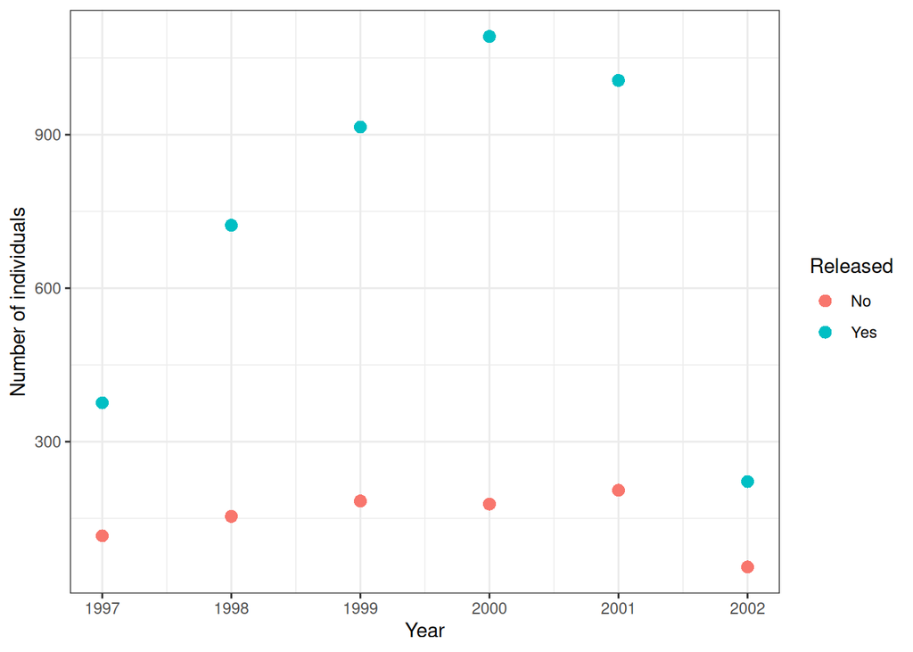

4. **(2 pkt.)** Przy pomocy testów $\chi^2$ Pearsona dla macierzy kontyngencji sprawdź czy zmienna `released` jest zależna od zmiennych `colour`, `sex` oraz `citizen`. Udziel odpowiedzi w komentarzu.

```
##
##  Pearson's Chi-squared test with Yates' continuity correction
##
## data:  t1
## X-squared = 92.381, df = 1, p-value < 2.2e-16
```

```
##
##  Pearson's Chi-squared test with Yates' continuity correction
##
## data:  t2
## X-squared = 2.5567, df = 1, p-value = 0.1098
```

```
##
##  Pearson's Chi-squared test with Yates' continuity correction
##
## data:  t3
## X-squared = 68.622, df = 1, p-value < 2.2e-16
```

5. **(3 pkt.)** Wykonaj histogram zmiennej wiek zbudowany z ok. 20 binów. Przy pomocy funkcji `fitdistr()` oraz `ks.test()` zweryfikuj jaki rozkład najlepiej opisuje tę zmienną. Wybierz pośród rozkładów Poissona, Weibulla oraz Gamma. Nanieś teoretyczne gęstości rozkładów na histogram w postaci kolorowych ciągłych linii i dodaj legendę. Do wykonania wykresu można użyć pakietu podstawowego lub `ggplot2`

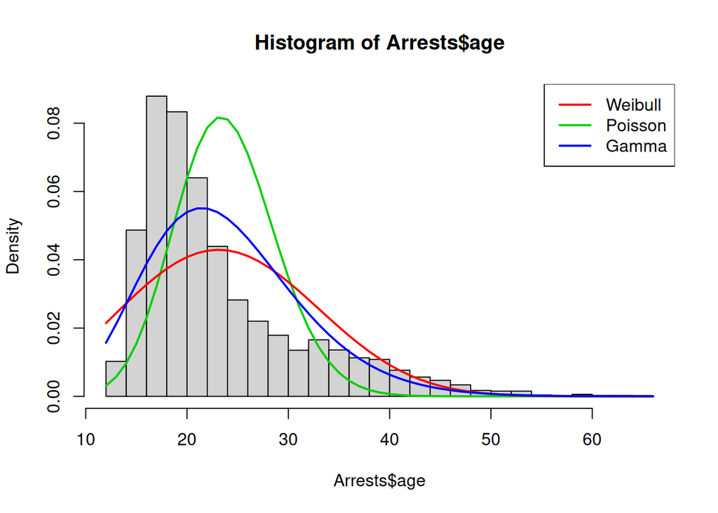